# About

Jessica Edwards

2/27/2020

## Summary and Goals

This project’s goal is to analyze students studying STEM at the university level and to break down and compare racial and gender demographics between highly ranked institutions within the United States. This data is collected from the [American Society for Engineering Education (ASEE)](https://www.asee.org/).

This investigation hopes to critique the current demographic breakdown of STEM fields and encourage higher institutions to think more about how they can help encourage underrepresented minorities to enter and remain interested in STEM fields.

So far in my project, I have currently found and cleaned data tables on Degrees Awarded by Program in 2018. These tables provide the racial and gender breakdowns within STEM degrees awarded at each school.

I would also like to analyze the number of students studying each field in total over a longer time span to see if the racial and gender breakdowns changes significantly over time.

Additionally, there are tables on the ASEE website that break down each field based on how many students identify as male or female within each race which may be interesting to incorporate in my project.

Finally, I may consider including data about K-12 STEM programs and career paths in my project in order to analyze if racial and gender breakdowns before and after college are similar.

#### Github Link: https://github.com/jessie9111/gov1005-final-project

## The Data

Brown University

Columbia University

Cornell University

Dartmouth College

Harvard University

University of Pennsylvania

Princeton University

Yale School of Engineering & Applied Science

Boston University

California Institute of Technology

University of California, Berkeley

Carnegie Mellon University

Duke University

Georgia Institute of Technology

Harvey Mudd College

Johns Hopkins University

Massachusetts Institute of Technology

Northwestern University

Tufts University

Vanderbilt University

University of Virginia

Washington University in St. Louis

## Visualizations

```r
# Is a higher percentage of underrepresented minority students (Black and Hispanic) at a school
# associated with more students graduating with engineering degrees in total?

blk_his <- race_all_schools %>%
  filter((perc != 0) & (race == "Blk" | race == "His")) %>%
  group_by(school) %>%
  summarize(total = mean(Total), perc = sum(perc))

lm(total ~ perc, blk_his)
```

```
##
## Call:
## lm(formula = total ~ perc, data = blk_his)
##
## Coefficients:
## (Intercept)         perc
##     1005.33       -30.92
```

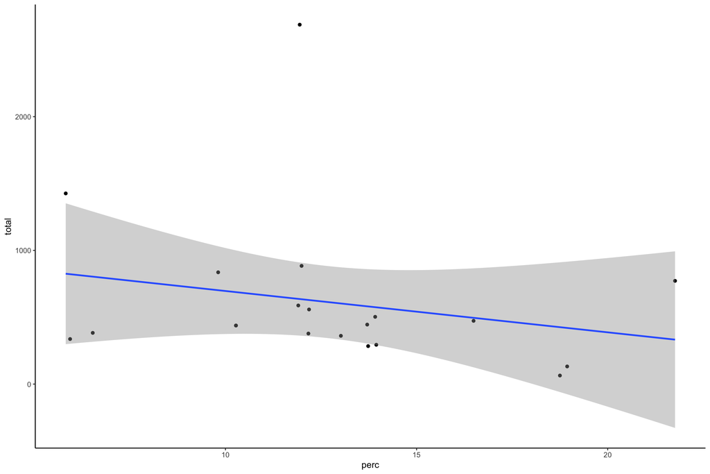

```r
ggplot(blk_his, aes(x = perc, y = total)) + geom_point() + theme_classic() + geom_smooth(method = "lm")
```

```r
# Is a higher percentage of female students at a school associated with more
# students graduating with engineering degrees in total?

fem <- gender_all_schools %>%
  filter(gender == "Female")

lm(Total ~ perc, fem)
```

```
##
## Call:
## lm(formula = Total ~ perc, data = fem)
##
## Coefficients:
## (Intercept)         perc
##     2100.99       -43.78
```

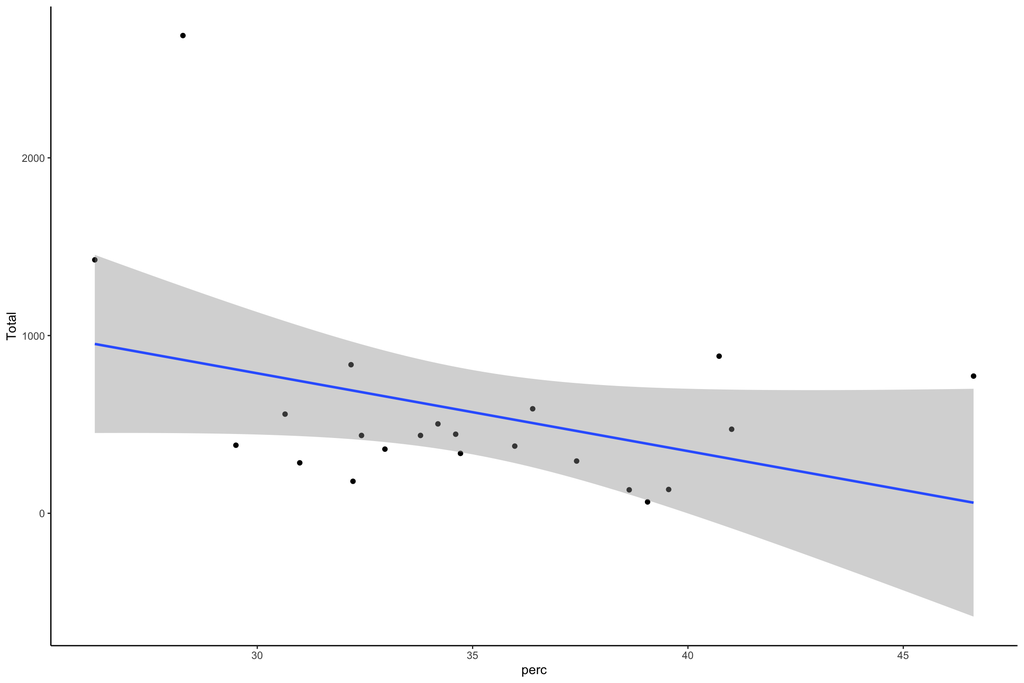

```r
ggplot(fem, aes(x = perc, y = Total)) + geom_point() + theme_classic() + geom_smooth(method = "lm")
```